# DATA PREPROCESSING WITH R

Masking xảy ra khi dữ liệu là các các giá trị ngoại lệ nhưng chúng ta không phát hiện được chúng. Điều này có thể xảy ra vì một số outliers có thể bị ẩn bởi các outliers khác trong dữ liệu. Swamping xảy ra khi chúng ta xác định sai một số điểm không phải outliers là outliers. Điều này có thể xảy ra do các điểm nằm ngoài có xu hướng kéo phương trình hồi quy về phía chúng, do đó làm cho các điểm khác nằm xa đường hồi quy. Vì vậy, masking là một quyết định false negative trong khi việc swamping là một quyết false positve.

Phép kiểm tra các giá trị ngoại lệ của Rosner có ưu điểm là:

1. Nó được sử dụng để phát hiện nhiều ngoại lệ cùng một lúc
2. Nó được thiết kế để tránh vấn đề masking, trong đó một ngoại lệ có giá trị gần với một ngoại lệ khác có thể không bị phát hiện.

```r
library(EnvStats)
rosnerTest(cars$dist, k = 3)
```

```
##
## Results of Outlier Test
## -------------------------
##
## Test Method:                     Rosner's Test for Outliers
##
## Hypothesized Distribution:       Normal
##
## Data:                            cars$dist
##
## Sample Size:                     50
##
## Test Statistics:                 R.1 = 2.988819
##                                  R.2 = 2.196316
##                                  R.3 = 2.297508
##
## Test Statistic Parameter:        k = 3
##
## Alternative Hypothesis:          Up to 3 observations are not
##                                  from the same Distribution.
##
## Type I Error:                    5%
##
## Number of Outliers Detected:     0
##
##   i   Mean.i     SD.i Value Obs.Num    R.i+1 lambda.i+1 Outlier
## 1 0 42.98000 25.76938   120      49 2.988819   3.128247   FALSE
## 2 1 41.40816 23.49017    93      48 2.196316   3.120128   FALSE
## 3 2 40.33333 22.48814    92      47 2.297508   3.111796   FALSE
```

- Residual plot

```r
mod <- lm(dist~speed, data=cars)
resid(mod)
```

```
##          1          2          3          4          5          6          7
##   3.849460  11.849460  -5.947766  12.052234   2.119825  -7.812584  -3.744993
##          8          9         10         11         12         13         14
##   4.255007  12.255007  -8.677401   2.322599 -15.609810  -9.609810  -5.609810
##         15         16         17         18         19         20         21
##  -1.609810  -7.542219   0.457781   0.457781  12.457781 -11.474628  -1.474628
##         22         23         24         25         26         27         28
##  22.525372  42.525372 -21.407036 -15.407036  12.592964 -13.339445  -5.339445
##         29         30         31         32         33         34         35
## -17.271854  -9.271854   0.728146 -11.204263   2.795737  22.795737  30.795737
##         36         37         38         39         40         41         42
## -21.136672 -11.136672  10.863328 -29.069080 -13.069080  -9.069080  -5.069080
##         43         44         45         46         47         48         49
##   2.930920  -2.933898 -18.866307  -6.798715  15.201285  16.201285  43.201285
##         50
##   4.268876
```

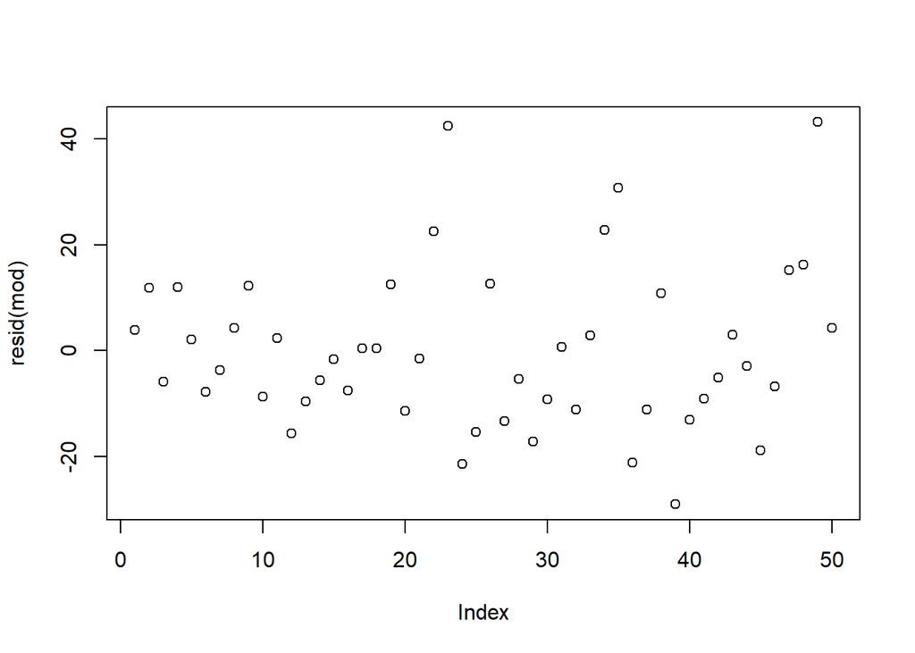

```r
plot(resid(mod))
```

- QQ plot

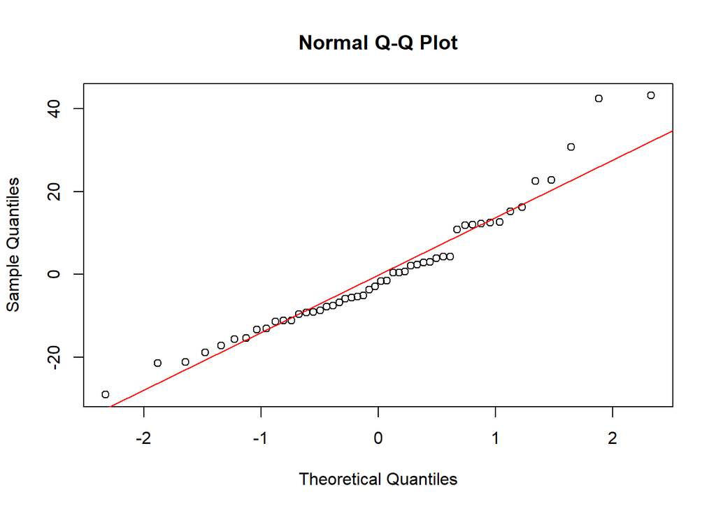

```r
qqnorm(resid(mod))
qqline(resid(mod), col = "red")
```

## 4.4 Cách xác định Leverage point

- Leverage statistic (Hat matrix): Ma trận mũ là một công cụ chẩn đoán định lượng mức độ ảnh hưởng của từng quan sát đối với các y mũ. Điểm có đòn bẩy cao có tác động lớn hơn đến các hệ số beta.

Ta có: $Y = X\beta + \epsilon$

và

$\hat{y} = Xb$

$b = (X'X)^{-1} X'y$

Ta được: $\hat{y} = X(X'X)^{-1}X'y$

Đặt $H = X(X'X)^{-1}X'$ với $H$ là ma trận $n*n$ ta được:

$\hat{y} = Hy$

Ta có được giá trị y mũ thứ {i} sẽ là tổ hợp tuyến tính của $n$ quan sát $y_{1}, y_{2}, ..., y_{n}$:

$\hat{y} = h_{i1}y_{1} + h_{i2}y_{2} + ...+ h_{in}y_{n}$ với $i = 1, ...,n$

Xác định các điểm dữ liệu có cực trị $x$:

$\overline{h} = \frac{\Sigma_{i=1}^{n}h_{ii}}{n} = \frac{k+1}{n}$

Ta thường loại bỏ các điểm dữ liệu với:

$h_{ii} > 3\frac{k+1}{n}$

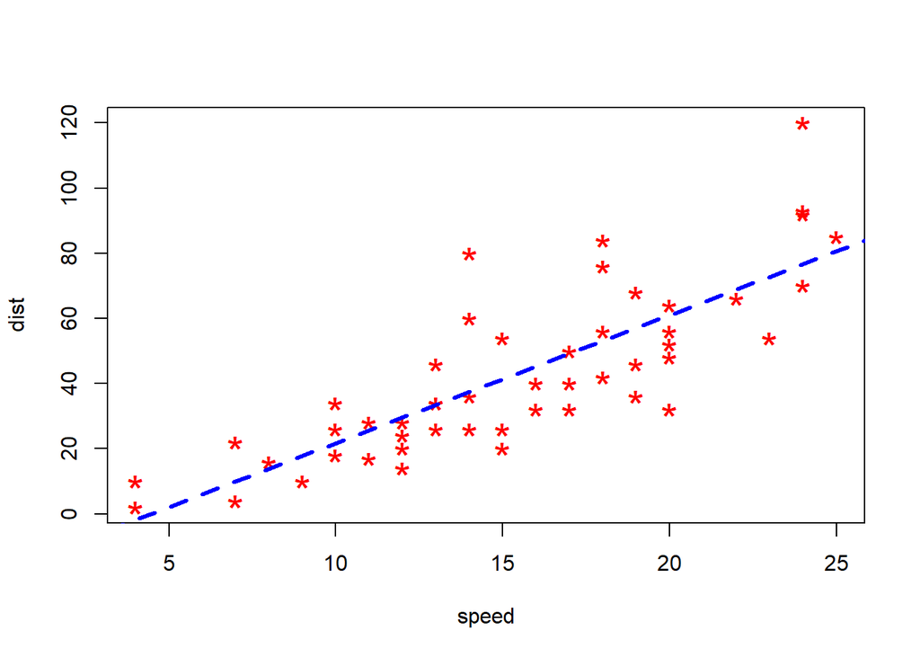

```r
plot(cars$speed, cars$dist, xlab="speed", ylab="dist", pch="*", col="red", cex=2)
abline(lm(dist ~ speed, data=cars), col="blue", lwd=3, lty=2)
```

```r
influence(mod)$hat
```

```
##          1          2          3          4          5          6          7
## 0.11486131 0.11486131 0.07150365 0.07150365 0.05997080 0.04989781 0.04128467
##          8          9         10         11         12         13         14
## 0.04128467 0.04128467 0.03413139 0.03413139 0.02843796 0.02843796 0.02843796
##         15         16         17         18         19         20         21
## 0.02843796 0.02420438 0.02420438 0.02420438 0.02420438 0.02143066 0.02143066
##         22         23         24         25         26         27         28
## 0.02143066 0.02143066 0.02011679 0.02011679 0.02011679 0.02026277 0.02026277
##         29         30         31         32         33         34         35
## 0.02186861 0.02186861 0.02186861 0.02493431 0.02493431 0.02493431 0.02493431
##         36         37         38         39         40         41         42
## 0.02945985 0.02945985 0.02945985 0.03544526 0.03544526 0.03544526 0.03544526
##         43         44         45         46         47         48         49
## 0.03544526 0.05179562 0.06216058 0.07398540 0.07398540 0.07398540 0.07398540
##         50
## 0.08727007
```

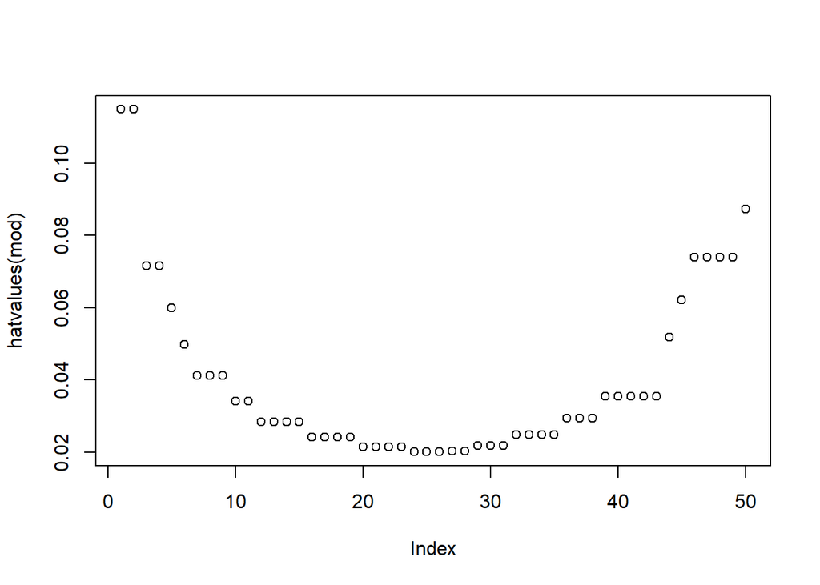

```r
plot(hatvalues(mod))
```

- Cook’s distance

$D_{i} = \frac{(y_{i}-\hat{y}_{i})^{2}}{(k+1)MSE}\frac{h_{ii}}{(1-h_{ii})^{2}}$

$D_{i}$ cho thấy mức độ thay đổi của tất cả các giá trị dự báo khi quan sát thứ $i$ bị xóa. Điểm dữ liệu có $D_{i}$ lớn chỉ ra rằng điểm dữ liệu ảnh hưởng mạnh đến các giá trị dư báo.

```r
cooks.distance(mod)
```

```
##            1            2            3            4            5            6
## 4.592312e-03 4.351399e-02 6.202350e-03 2.546734e-02 6.446705e-04 7.131993e-03
##            7            8            9           10           11           12
## 1.331656e-03 1.719059e-03 1.425993e-02 5.823417e-03 4.172024e-04 1.551791e-02
##           13           14           15           16           17           18
## 5.881222e-03 2.004169e-03 1.650393e-04 3.056717e-03 1.126088e-05 1.126088e-05
##           19           20           21           22           23           24
## 8.339467e-03 6.228883e-03 1.028721e-04 2.400363e-02 8.555181e-02 2.029569e-02
##           25           26           27           28           29           30
## 1.051305e-02 7.023387e-03 7.940281e-03 1.272192e-03 1.441403e-02 4.153753e-03
##           31           32           33           34           35           36
## 2.561795e-05 6.959480e-03 4.333142e-04 2.880829e-02 5.257647e-02 2.953639e-02
##           37           38           39           40           41           42
## 8.199645e-03 7.802074e-03 6.805305e-02 1.375546e-02 6.623866e-03 2.069395e-03
##           43           44           45           46           47           48
## 6.918196e-04 1.048238e-03 5.317562e-02 8.430333e-03 4.214554e-02 4.787292e-02
##           49           50
## 3.403959e-01 4.035418e-03
```

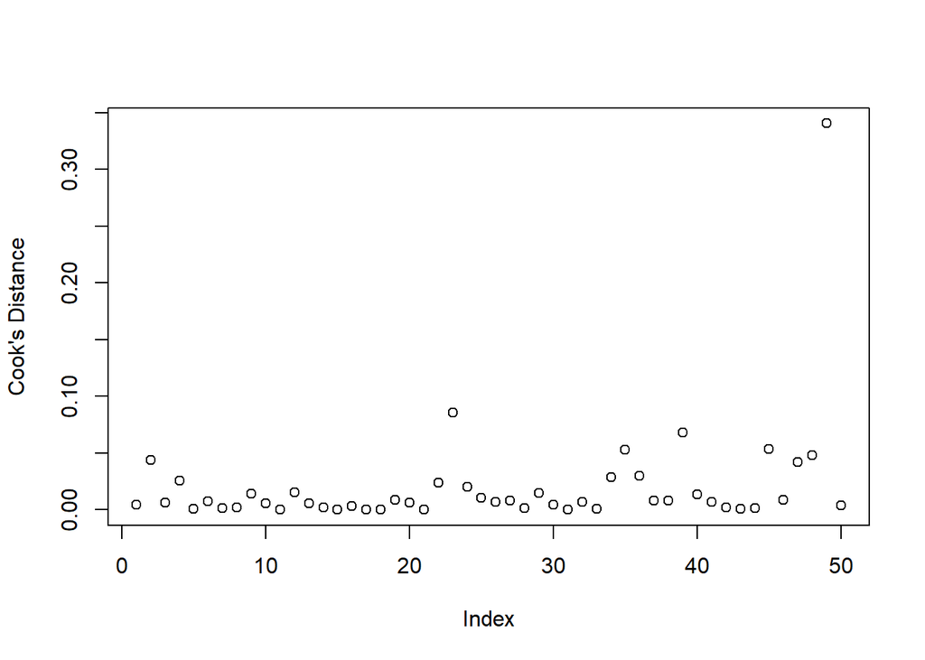

```r
plot(cooks.distance(mod),ylab="Cook's Distance")
```

## 4.5 Cách xác định Influential Point

Ta sẽ loại bỏ thử giá trị dist = 120 và xem thử kết quả hồi quy có bị thay đổi nhiều không

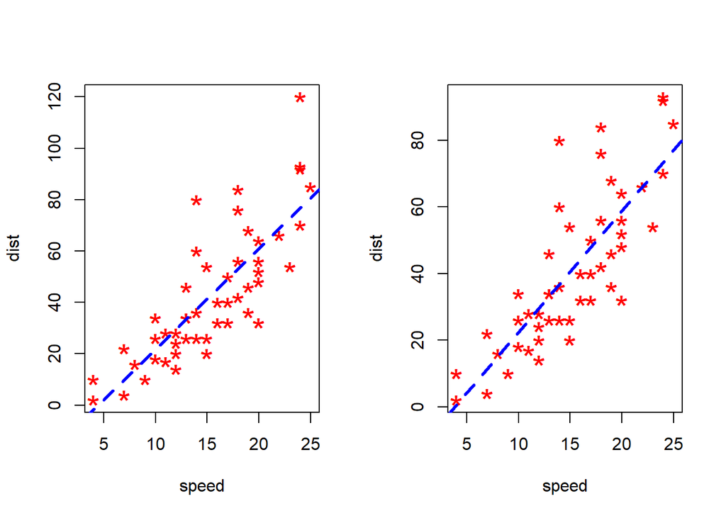

```r
cars1 <- subset(cars, cars$dist != 120)

par(mfrow = c(1, 2))

plot(cars$speed, cars$dist, xlab="speed", ylab="dist", pch="*", col="red", cex=2)
abline(lm(dist ~ speed, data=cars), col="blue", lwd=3, lty=2)

plot(cars1$speed, cars1$dist, xlab="speed", ylab="dist", pch="*", col="red", cex=2)
abline(lm(dist ~ speed, data=cars1), col="blue", lwd=3, lty=2)
```

Ta sẽ xem kết quả 2 model:

```r
summary(mod)
```

```
##
## Call:
## lm(formula = dist ~ speed, data = cars)
##
## Residuals:
##     Min      1Q  Median      3Q     Max
## -29.069  -9.525  -2.272   9.215  43.201
##
## Coefficients:
##             Estimate Std. Error t value Pr(>|t|)
## (Intercept) -17.5791     6.7584  -2.601   0.0123 *
## speed         3.9324     0.4155   9.464 1.49e-12 ***
## ---
## Signif. codes:  0 '***' 0.001 '**' 0.01 '*' 0.05 '.' 0.1 ' ' 1
##
## Residual standard error: 15.38 on 48 degrees of freedom
## Multiple R-squared:  0.6511, Adjusted R-squared:  0.6438
## F-statistic: 89.57 on 1 and 48 DF,  p-value: 1.49e-12
```

```r
mod1 <- lm(dist ~ speed, data=cars1)
summary(mod1)
```

```
##
## Call:
## lm(formula = dist ~ speed, data = cars1)
##
## Residuals:
##     Min      1Q  Median      3Q     Max
## -26.789  -9.149  -1.672   8.013  43.048
##
## Coefficients:
##             Estimate Std. Error t value Pr(>|t|)
## (Intercept) -14.0021     6.2951  -2.224    0.031 *
## speed         3.6396     0.3918   9.290 3.26e-12 ***
## ---
## Signif. codes:  0 '***' 0.001 '**' 0.01 '*' 0.05 '.' 0.1 ' ' 1
##
## Residual standard error: 14.1 on 47 degrees of freedom
## Multiple R-squared:  0.6474, Adjusted R-squared:  0.6399
## F-statistic: 86.31 on 1 and 47 DF,  p-value: 3.262e-12
```

Thêm một quan sát là influential point vào tập dữ liệu

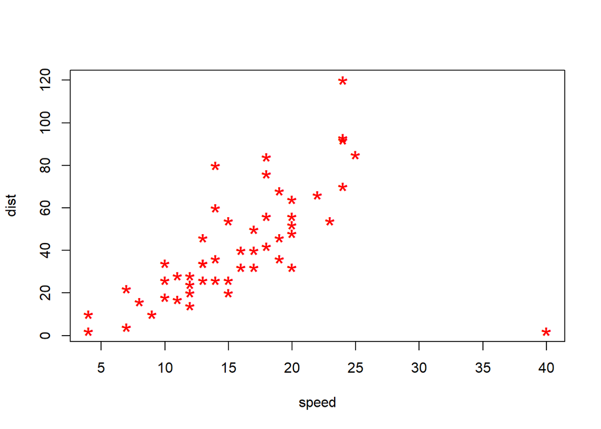

```r
library(dplyr)
cars_outliers <- data.frame(speed=40, dist=2)  # introduce outliers.
cars2 <- bind_rows(cars, cars_outliers)  # data with outliers.

plot(dist~speed, data=cars2, pch="*", col="red", cex=2)
```

Xem xét lại 2 mô hình hồi quy:

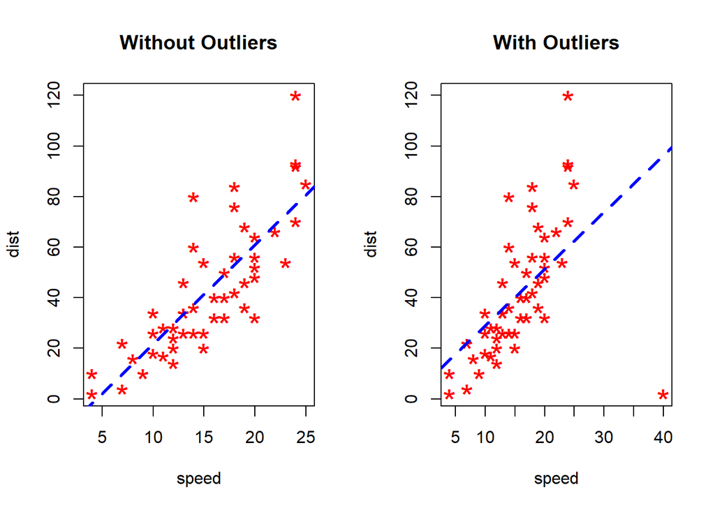

```r
par(mfrow = c(1, 2))

plot(cars$speed, cars$dist, xlab="speed", ylab="dist", main="Without Outliers", pch="*", col="red", cex=2)
abline(lm(dist ~ speed, data=cars), col="blue", lwd=3, lty=2)

plot(cars2$speed, cars2$dist, xlab="speed", ylab="dist", main="With Outliers", pch="*", col="red", cex=2)
abline(lm(dist ~ speed, data=cars2), col="blue", lwd=3, lty=2)
```

```r
summary(mod)
```

```
##
## Call:
## lm(formula = dist ~ speed, data = cars)
##
## Residuals:
##     Min      1Q  Median      3Q     Max
## -29.069  -9.525  -2.272   9.215  43.201
##
## Coefficients:
##             Estimate Std. Error t value Pr(>|t|)
## (Intercept) -17.5791     6.7584  -2.601   0.0123 *
## speed         3.9324     0.4155   9.464 1.49e-12 ***
## ---
## Signif. codes:  0 '***' 0.001 '**' 0.01 '*' 0.05 '.' 0.1 ' ' 1
##
## Residual standard error: 15.38 on 48 degrees of freedom
## Multiple R-squared:  0.6511, Adjusted R-squared:  0.6438
## F-statistic: 89.57 on 1 and 48 DF,  p-value: 1.49e-12
```

```r
mod2 <- lm(dist ~ speed, data=cars2)
summary(mod2)
```

```
##
## Call:
## lm(formula = dist ~ speed, data = cars2)
##
## Residuals:
##     Min      1Q  Median      3Q     Max
## -94.216 -11.477  -3.162   9.875  59.635
##
## Coefficients:
##             Estimate Std. Error t value Pr(>|t|)
## (Intercept)   6.5896     8.5748   0.768    0.446
## speed         2.2407     0.5029   4.456 4.86e-05 ***
## ---
## Signif. codes:  0 '***' 0.001 '**' 0.01 '*' 0.05 '.' 0.1 ' ' 1
##
## Residual standard error: 22.28 on 49 degrees of freedom
## Multiple R-squared:  0.2883, Adjusted R-squared:  0.2738
## F-statistic: 19.85 on 1 and 49 DF,  p-value: 4.858e-05
```

- Difference in Fits (DFFITS) và DFBETAS Ý tưởng cơ bản đằng sau mỗi thước đo này là giống nhau, cụ thể là xóa từng quan sát một, mỗi lần điều chỉnh lại mô hình hồi quy trên n–1 quan sát còn lại.

$DFFITS_{i} = \frac{\hat{y}_{i}-\hat{y}_{(i)}}{\sqrt(S^{2}_{i}h_{ii})}$

với $\hat{y}_{i}$ là giá trị dự báo cho quan sát thứ $i$ với quan sát $i$ có trong mô hình và $\hat{y}_{(i)}$ là giá trị dự báo cho quan sát thứ $i$ với quan sát $i$ không có trong mô hình

$DFBETAS_{i} = \frac{\hat{\beta}_{j}-\hat{\beta}_{j(i)}}{\sqrt(S^{2}_{i}C_{jj})}$

với $C_{jj}$ là vị trí thứ $j$ trên đường chéo của ma trận $(X'X)^{-1}$ và $S^{2}_{(i)}$ là ước lượng cho $\sigma^{2}$ khi không có quan sát thứ $i$.

DFBETAS đo lường mức độ ảnh hưởng của quan sát thứ $i$ tới giá trị $\beta_{j}$ trong khi DFFITS đo lường ảnh hưởng của quan sát thứ $i$ tới giá trị $\hat{y}_{i}$

Quan sát thứ $i$ cần được xem xét nếu:

$\mid{DFBETAS_{j,i}\mid} > \frac{2}{\sqrt(n)}$

```r
library(olsrr)
dfbetas(mod2)
```

```
##      (Intercept)         speed
## 1  -0.2001061840  0.1784353300
## 2  -0.0816976108  0.0728500232
## 3  -0.2067055288  0.1743435386
## 4  -0.0030789480  0.0025969053
## 5  -0.0865039471  0.0710290061
## 6  -0.1531842321  0.1216245504
## 7  -0.0888121028  0.0675248496
## 8  -0.0241410402  0.0183547068
## 9   0.0403313040 -0.0306643481
## 10 -0.1007439808  0.0722769295
## 11 -0.0228110058  0.0163653396
## 12 -0.1188638142  0.0785633809
## 13 -0.0819010274  0.0541327203
## 14 -0.0574812209  0.0379923788
```

[output cut: 37 more lines]

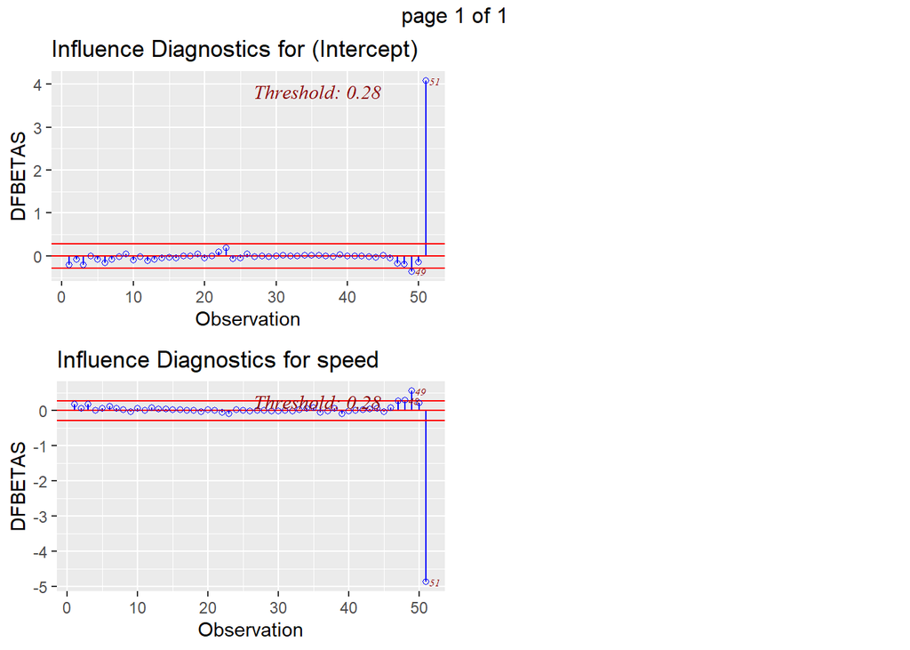

```r
ols_plot_dfbetas(mod2)
```

```r
dffits(mod2)
```

```
##            1            2            3            4            5            6
## -0.201296328 -0.082183512 -0.212665662 -0.003167726 -0.090393686 -0.163752030
##            7            8            9           10           11           12
## -0.098144374 -0.026677752  0.044569270 -0.116877442 -0.026464033 -0.148108645
##           13           14           15           16           17           18
## -0.102051666 -0.071623697 -0.041342238 -0.068412640 -0.012071729 -0.012071729
##           19           20           21           22           23           24
##  0.072398586 -0.079669398 -0.013011149  0.147913994  0.290216818 -0.130613318
##           25           26           27           28           29           30
## -0.091414497  0.088825765 -0.066398174 -0.015485155 -0.082074241 -0.030206886
##           31           32           33           34           35           36
##  0.034332298 -0.033084560  0.061106937  0.198951664  0.256663193 -0.094270510
##           37           38           39           40           41           42
## -0.022569386  0.135446445 -0.150249730 -0.026145340  0.004588527  0.035331717
##           43           44           45           46           47           48
##  0.097097207  0.092117206 -0.040914335  0.104435248  0.349897266  0.361485390
##           49           50           51
##  0.701527728  0.266880442 -5.032708629
```

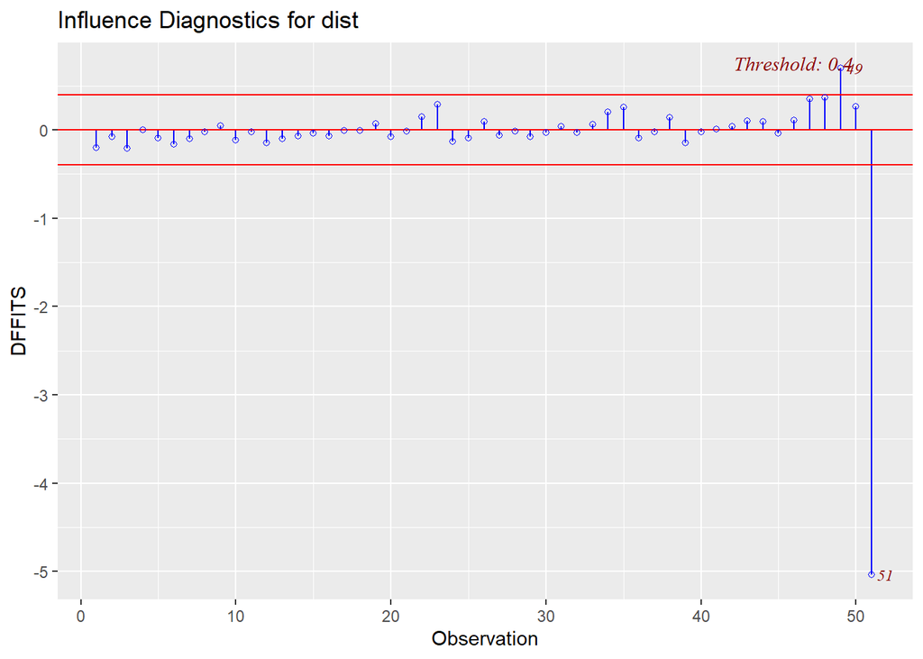

```r
ols_plot_dffits(mod2)
```

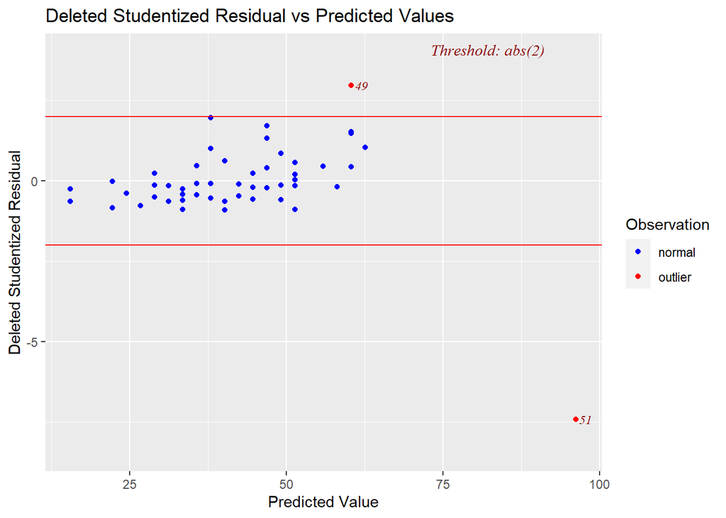

```r
ols_plot_resid_stud_fit(mod2)
```

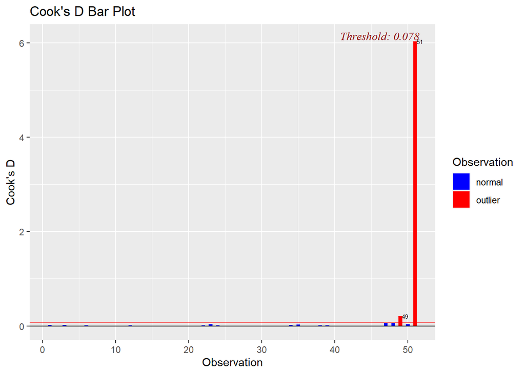

```r
ols_plot_cooksd_bar(mod2)
```

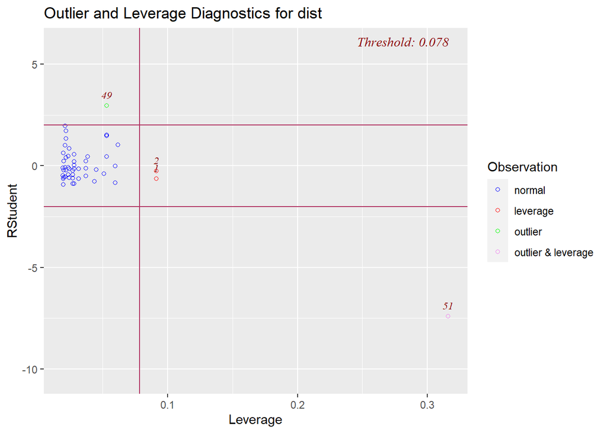

```r
ols_plot_resid_lev(mod2)
```

Những cách xác định trên hiện đang dùng cho từng điểm dữ liệu chúng ta có thể mở rộng lên cho nhóm từ 2 hoặc nhiều hơn các điểm dữ liệu khác theo cách tương tự. Tuy nhiên, với nhóm các outliers thì nên dùng phương pháp cluster analysis sẽ hiệu quả hơn.

## 4.6 Xử lý Outliers (influential)

- Loại chúng nếu như chúng là lỗi
- Giữ chúng nếu chúng thực sự có giá trị
- Dùng robust estimation, đổi hàm lỗi của hồi quy tuyến tính thành $\Sigma|e^{i}|$ sang $\Sigma|e_{i}|$

## 4.7 Weight least square

Khi có outliers trong tập dữ liệu và ta thực hiện mô hình hồi quy tuyến tính thì sẽ xuất hiện hiện tượng phương sai sai số khác nhau:

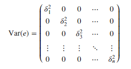

var

Với $\delta_{1}^{2}\neq\delta_{2}^{2}...\neq\delta_{n}^{2}$

Giả sử rằng phương sai của phần dư của quan sát thứ $i$ là:

$Var(e_{i})=\delta^{2}_{i}=\frac{\sigma^{2}}{w_{i}}$

Với $w_{1}, ..., w_{n}$ là các số dương chưa biết.

Khi đó, chúng ta sẽ cần tìm các hệ số hồi quy bằng việc đi tìm cực tiểu của hàm tổng số dư bình phương có trọng số sau đây:

$RSS(\beta_{0}, \beta_{1})=\Sigma_{i=1}^{n}w_{i}(Y_{i}-\beta_{0}-\beta_{1}X_{i})^{2}$

Bỏ qua các phép toán ta có được kết quả:

$\hat{\beta} = (X'WX)^{-1}(X'WY)$

```r
# weights
wt <- 1/lm(abs(mod2$residuals) ~ mod2$fitted.values)$fitted.values^2

# WLS
wls_mod <- lm(dist ~ speed, data = cars2, weights = wt)

# summary
summary(wls_mod)
```

```
##
## Call:
## lm(formula = dist ~ speed, data = cars2, weights = wt)
##
## Weighted Residuals:
##     Min      1Q  Median      3Q     Max
## -5.8946 -0.7389 -0.1337  0.6766  5.4180
##
## Coefficients:
##             Estimate Std. Error t value Pr(>|t|)
## (Intercept)  -8.9190     3.4056  -2.619   0.0117 *
## speed         3.1854     0.3948   8.069  1.5e-10 ***
## ---
## Signif. codes:  0 '***' 0.001 '**' 0.01 '*' 0.05 '.' 0.1 ' ' 1
##
## Residual standard error: 1.635 on 49 degrees of freedom
## Multiple R-squared:  0.5706, Adjusted R-squared:  0.5618
## F-statistic: 65.11 on 1 and 49 DF,  p-value: 1.499e-10
```

```r
summary(mod2)
```

```
##
## Call:
## lm(formula = dist ~ speed, data = cars2)
##
## Residuals:
##     Min      1Q  Median      3Q     Max
## -94.216 -11.477  -3.162   9.875  59.635
##
## Coefficients:
##             Estimate Std. Error t value Pr(>|t|)
## (Intercept)   6.5896     8.5748   0.768    0.446
## speed         2.2407     0.5029   4.456 4.86e-05 ***
## ---
## Signif. codes:  0 '***' 0.001 '**' 0.01 '*' 0.05 '.' 0.1 ' ' 1
##
## Residual standard error: 22.28 on 49 degrees of freedom
## Multiple R-squared:  0.2883, Adjusted R-squared:  0.2738
## F-statistic: 19.85 on 1 and 49 DF,  p-value: 4.858e-05
```

So sánh hai phương trình hồi quy:

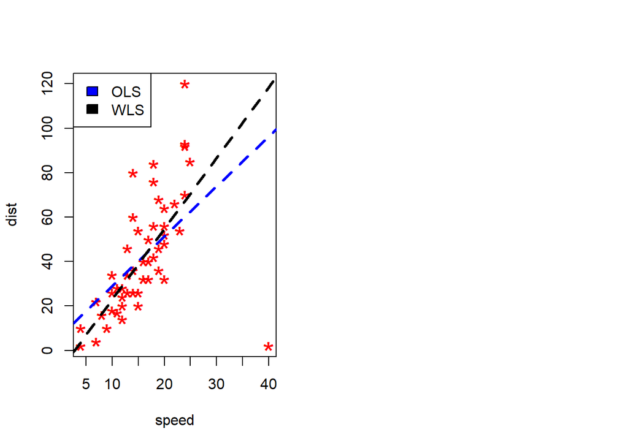

```r
par(mfrow = c(1, 2))

plot(cars2$speed, cars2$dist, xlab="speed", ylab="dist", pch="*", col="red", cex=2)

abline(lm(dist ~ speed, data=cars2), col="blue", main="OLS", lwd=3, lty=2)

abline(lm(dist ~ speed, data = cars2, weights = wt), col="black", main="WLS", lwd=3, lty=2)

legend(x = "topleft", legend=c("OLS", "WLS"), fill=c("blue","black"))
```

# 5 OBVIOUS INCONSISTENCIES

## 5.1 Create an inconsistent sample

Manual creating a sample dataset contains obvious inconsistencies:

```r
gen_data <- read.csv('E:\\MSc.Data-Science\\Mo-hinh-hoa-thong-ke\\Project\\Group\\gen_data.csv', header=T)
head(gen_data)
```

```
##   age agegroup height  status yearsmarried
## 1  21    adult    6.0  single           -1
## 2   2    child    3.0 married            0
## 3  18    adult    5.7 married           20
## 4 221  elderly    5.0 widowed            2
## 5  34    child   -7.0 married            3
```

Notify that:

- 0 $<$ age $<$ 150
- height > 0
- agegroup = **‘child’** can not get **‘married’** value in status
- yearsmarried > 0

## 5.2 Step 1

**To fix this we can use the library: editrules**  
Creating a text file named: *edits.txt* containing rules:

- numerical rules:
  - age >= 0
  - age <= 150
  - height > 0
  - age > yearsmarried
- categorical rules:
  - status %in% c(“married”,“single”,“widowed”)
  - agegroup %in% c(“child”,“adult”,“elderly”)
  - if (status == “married”) agegroup %in% c(“adult”,“elderly”)
- mixed rules
  - if ( status %in% c(“married”,“widowed”)) age - yearsmarried >= 18
  - if ( age < 18 ) agegroup == “child”
  - if ( age >= 18 && age <65 ) agegroup == “adult”
  - if ( age >= 65 ) agegroup == “elderly”

## 5.3 Step 2

Using package **editrules** to check:

```r
edit <- editfile(file.choose())
edit
```

```
##
## Data model:
## dat5 : agegroup %in% c('adult', 'child', 'elderly')
## dat6 : status %in% c('married', 'single', 'widowed')
##
## Edit set:
## num1 : 0 <= age
## num2 : age <= 150
## num3 : 0 < height
## num4 : yearsmarried < age
## num5 : yearsmarried + 18 <= age
## cat6 : if( agegroup == 'child' ) status != 'married'
## mix7 : if( age < 18 ) !( agegroup %in% c('adult', 'elderly') )
## mix8 : if( 18 <= age & age < 65 ) !( agegroup %in% c('child', 'elderly') )
## mix9 : if( 65 <= age ) !( agegroup %in% c('adult', 'child') )
```

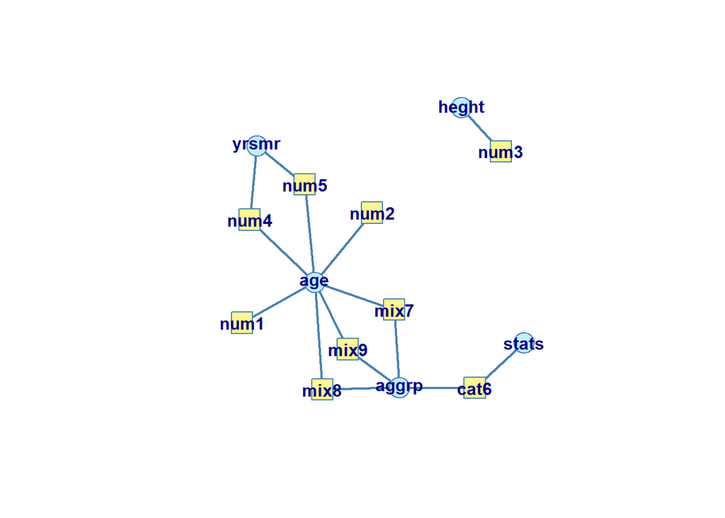

```r
plot(edit)
```

```r
ve <- violatedEdits(edit, gen_data)
print(ve)
```

```
##       edit
## record  num1  num2  num3  num4  num5  dat5  dat6  cat6  mix7  mix8  mix9
##      1 FALSE FALSE FALSE FALSE FALSE FALSE FALSE FALSE FALSE FALSE FALSE
##      2 FALSE FALSE FALSE FALSE  TRUE FALSE FALSE  TRUE FALSE FALSE FALSE
##      3 FALSE FALSE FALSE  TRUE  TRUE FALSE FALSE FALSE FALSE FALSE FALSE
##      4 FALSE  TRUE FALSE FALSE FALSE FALSE FALSE FALSE FALSE FALSE FALSE
##      5 FALSE FALSE  TRUE FALSE FALSE FALSE FALSE  TRUE FALSE  TRUE FALSE
```

```r
summary(ve, edit)
```

```
## Edit violations, 5 observations, 0 completely missing (0%):
##
##  editname freq rel
##      num5    2 40%
##      cat6    2 40%
##      num2    1 20%
##      num3    1 20%
##      num4    1 20%
##      mix8    1 20%
##                                                                 edit
##                                             yearsmarried + 18 <= age
##                        if( agegroup == 'child' ) status != 'married'
##                                                           age <= 150
##                                                           0 < height
##                                                   yearsmarried < age
##  if( 18 <= age & age < 65 ) !( agegroup %in% c('child', 'elderly') )
##
## Edit violations per record:
##
##  errors freq rel
##       0    1 20%
##       1    1 20%
##       2    2 40%
##       3    1 20%
```

## 5.4 Step 3. Find the location violated value

```r
for (col in colnames(ve)) {
  true_rows <- rownames(ve)[ve[, col]]
  if (length(true_rows) > 0) {
    cat("Column:", col, "\n")
    cat("Rows:", paste(true_rows, collapse = ", "), "\n\n")
  }
}
```

```
## Column: num2
## Rows: 4
##
## Column: num3
## Rows: 5
##
## Column: num4
## Rows: 3
##
## Column: num5
## Rows: 2, 3
##
## Column: cat6
## Rows: 2, 5
##
## Column: mix8
## Rows: 5
```

```r
true_combinations <- which(ve == TRUE, arr.ind = TRUE)
print(true_combinations)
```

```
##   record edit
## 4      4    2
## 5      5    3
## 3      3    4
## 2      2    5
## 3      3    5
## 2      2    8
## 5      5    8
## 5      5   10
```

# 6 TÀI LIỆU THAM KHẢO

Các sách được sử dụng để tham khảo được lưu tại [link](https://drive.google.com/drive/folders/1k07QJaWGhnixBJGtB8l2D21th_M6LmBE?usp=sharing)  
1. Little, R. J., & Rubin, D. B. (2019). Statistical analysis with missing data (Vol. 793). John Wiley & Sons.  
2. Van Buuren, S. (2018). Flexible imputation of missing data. CRC press.  
3. Suri, N. M. R., Murty, M. N., & Athithan, G. (2019). Outlier detection: techniques and applications. Springer Nature.